# index

[figure not shown]

[figure not shown]

[figure not shown]

[figure not shown]

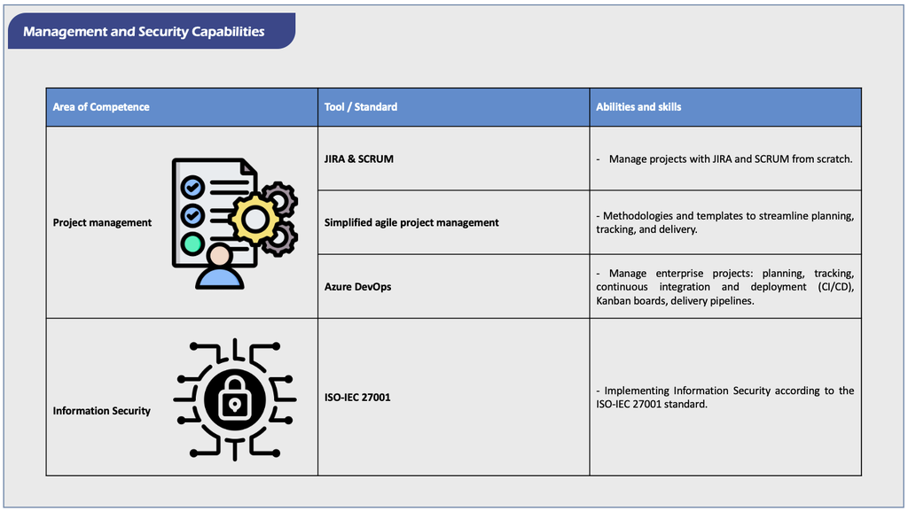

# Project: Microsoft Azure

## Overview

In the **prj-data-azure** project, I led the design and implementation of a **Data Lake architecture on Microsoft Azure**, based on Raw, Enriched, and Curated layers (Medallion Model). I designed ingestion pipelines with Azure Data Factory and Databricks, optimizing data loading into Azure Data Lake Storage Gen2. I applied scalable transformations using Spark and Delta Lake to ensure ACID compliance and versioning, and orchestrated automated ETL/ELT workflows. Additionally, I defined partitioning schemes, security policies, and continuous monitoring to maintain the solution’s integrity, traceability, and high performance.

[figure not shown]

# Project: Azure Databricks

## Overview

In the **prj-data-databricks** project, I led the design and implementation of a Lakehouse on Azure Databricks, structured in **Bronze–Silver–Gold** layers. I automated the **ingestion** of alerts from an external API using Python notebooks and Databricks Jobs, storing them in Delta Lake with optimized partitioning. In the **Bronze** layer, I captured raw data; in **Silver**, I applied transformations, cleansing, and enrichment with Spark SQL; and in **Gold**, I built tables optimized for analytical consumption. I orchestrated workflows with Databricks Workflows, managed versioning with Unity Catalog, and established security policies and continuous monitoring to ensure performance and governance.

## Project Structure

[figure not shown]

### **1. Bronze Layer**

- Stores the downloaded unprocessed files in JSON format.
- Notebook:
  - `00-download_jsonfiles_alerts`
  - `00_download_jsonfile_investigations`

### **2. Silver Layer**

- Performs the initial data transformation, extracting relevant information.
- Structuring and cleaning data into intermediate tables.
- Tables:
  - `01-ingest_json_alerts_tb`
  - `01_ingest_json_investigations_tables`

### **3. Gold Layer**

- Contains processed data ready for analytical consumption.
- Tables:
  - `02_ingest_join_alert_investigations_tables`

### **4. Utilities**

- Contains reusable functions and scripts for data ingestion and transformation.
- Folder: `src/utils`

## **Use Cases**

- **Automated ingestion of alerts** from an API such as EMVO.
- **Transformation and storage of data** in Databricks for advanced analytics.
- **Integration with dashboards or reports** to visualize trends and patterns in alerts.

# Project in Microsoft Fabric

This project represents a workflow in **Microsoft Fabric** for data management and processing in a **Lakehouse**, from ingestion through to visualization in reporting tools.

## Project Structure

[figure not shown]

## Data Source

Data is ingested from two main sources:

- **API**: An external data source based on web services.
- **Data Lake Storage**: Cloud storage where raw/unprocessed data is kept.

## Ingestion

- **`dwflow_ingest_data`**: An automated process (likely Dataflows Gen2) that extracts data from the API and the Data Lake Storage.
- **`pl_df_Ingest_data`**: Likely represents a data pipeline in **Data Factory** or **Synapse Dataflows** that processes and standardizes the data before landing it in the Lakehouse.

## Transform & Storage

- **`Lakehouse_LK1`**: Represents a **Lakehouse in Microsoft Fabric**, where structured and semi-structured data is stored.
- **`nb_transform_data & dwflow_transform`**: Notebooks (probably using Spark/PySpark) and Dataflows used to perform data transformations within the Lakehouse.

## Reporting and Visualization

The transformed data in the Lakehouse is consumed by **Power BI** or other visualization platforms to produce reports and enable analysis.

# Pipeline Deployment (DevOps)

I deploy pipelines in Azure DevOps for source integration and their continuous delivery.

## Diagram

[figure not shown]